# Commercial Fishing

## Tidy Tuesday

This is my seventh contribution to TidyTuesday, which is ‘a weekly podcast and community activity brought to you by the R4DS Online Learning Community.’ Their goal is to help R learners learn in real-world contexts.

For more information, visit the [TidyTuesday homepage](https://www.tidytuesday.com/), check out their [GitHub repository](https://github.com/rfordatascience/tidytuesday) and follow the [R4DS Learning Community on Twitter](https://twitter.com/R4DScommunity).

The purpose of these posts is mainly for exercising purposes. Thus, the provided graphs are not necessarily designed to provide the greatest possible insights. However, I always provide the R code for interested people at the page bottom.

## Commercial Fishing

This week’s data comes from [Great Lakes Fishery Commission](http://www.glfc.org/great-lakes-databases.php) provided by (Baldwin, N.S., Saalfeld, R.W., Dochoda, M.R., Buettner, H.J., Eshenroder, R.L., and O’Gorman, R. 2018). It contains commercial fish catch data from the Great Lakes over a time horizon from 1867 to 2015.

### Evolution of fishing amounts of Chinook Salmon and Yellow Perch

In 1989, the first quagga mussels were discovered in the Erie Lake (Karatayev et al. 2014). They are considered an invasive species and originate from Ukraine in Eastern Europe. Since then, it has spread throughout all of the Big Lakes and their surrounding area. They contribute to cleansing of the water and thus to food scarcity for native fish such as the popular Chinook, or King Salmon. One of the known predators of the Quagga mussels is the Yellow Perch. I assume that it could have profited from the spread of the mussels.  
Quagga mussel population density reached its peak between 1998 and 2002. I am interested in whether the Chinook Salmon population has declined since the discovery of Quagga mussels in 1989 or around their population maximum between 1998 and 2002. Simultaneously, one could suspect an increase in the Yellow Perch population and hence their fishing rate.  
To get a descriptive picture, I first filter out the fishing rates of the Yellow Perch and Chinook Salmon and aggregate the numbers over all lakes in each year:

```r
# filter out chinook salmon and yellow perch
fishing <- fishing %>% filter(species == "Yellow Perch" | species == "Chinook Salmon") %>%
  filter(year >= 1992)
# get minimum time for each track
sumfish <- aggregate(fishing$values ~ fishing$year + fishing$species, FUN = sum)
names(sumfish) <- c("year", "species", "value")
```

Then, I plot the amount of fish caught for the Chinook Salmon and the Yellow Perch, respectively:

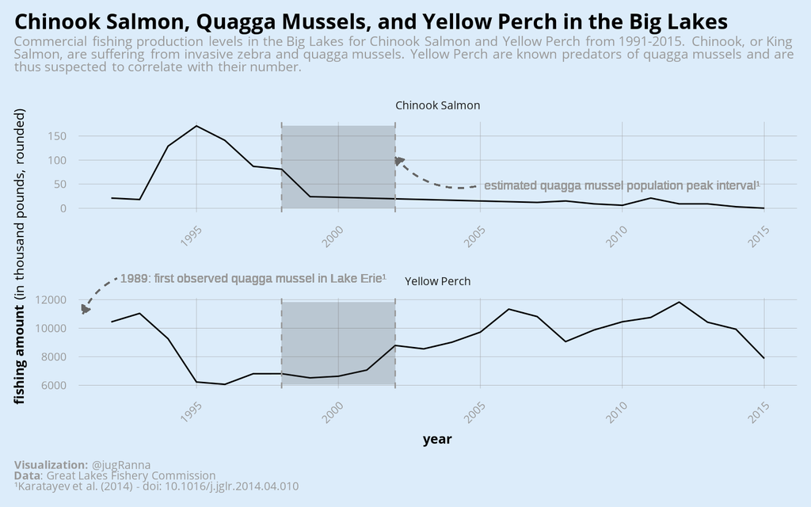

Full R code available on [Github](https://github.com/jgranna/tidytuesday/tree/main/2021-06-08).

## References

- `ggtext`**-package**:  
  https://wilkelab.org/ggtext/
- `patchwork`**-package**:  
  https://patchwork.data-imaginist.com/articles/patchwork.html
- `Rokemon`**-package**:  
  https://github.com/schochastics/rokemon
- `showtext`**-package**:  
  https://github.com/yixuan/showtext
- `tidyverse`**-package**:  
  https://www.tidyverse.org/

Baldwin, N.S., Saalfeld, R.W., Dochoda, M.R., Buettner, H.J., Eshenroder, R.L., and O’Gorman, R. 2018. “Commercial Fish Production in the Great Lakes 1867-2015 [online]. Available from http://www.glfc.org/great-lakes-databases.php [2021-06-09].”

Karatayev, Alexander Y., Lyubov E. Burlakova, Christopher Pennuto, Jan Ciborowski, Vadim A. Karatayev, Paul Juette, and Mark Clapsadl. 2014. “Twenty Five Years of Changes in Dreissena Spp. Populations in Lake Erie.” *Journal of Great Lakes Research* 40 (3): 550–59. https://doi.org/10.1016/j.jglr.2014.04.010.